# Project1XML

Chris Comora

10/17/2019

# Overview

The data being explored comes from the data.gov website and can be found here https://data.brla.gov/api/views/xsrb-mxqt/rows.xml. It contains summary statistics from the 2000 and 2010 United States Census including population, demographics, education, and housing information

The data is in the Extensible Markup Language (XML) format. It is a language that puts documents in a format that can be read by both humans and machines. “The design goals of XML emphasize simplicity, generality, and usability across the Internet.” (source: https://en.wikipedia.org/wiki/XML)

An XML file is generally organized into “nodes” with branches and child nodes. All together, the nodes make up the pieces of information that the file contains. Here’s a look at our raw file:

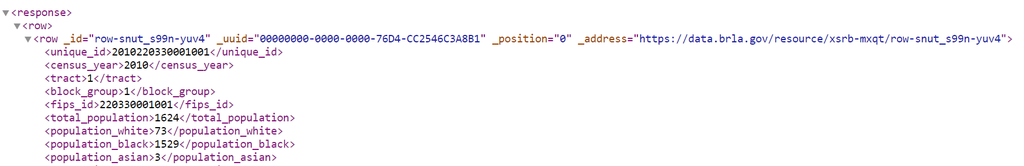

The next set of code will help us understand the file structure. We will use the XML package, which has several approaches for reading and creating XML documents. I chose this package because I found several helpful resources for applying the functions within, including this one: http://www.informit.com/articles/article.aspx?p=2215520

```r
#convert to xml document object
xmlfile <- xmlParse("census.xml")
xmltop <- xmlRoot(xmlfile) #gives contents of root
xmlName(xmltop) #gives name of node
```

```
## [1] "response"
```

```r
xmlSize(xmltop) #give number of children in node
```

```
## [1] 1
```

```r
xmlName(xmltop[[1]]) #name of root's children
```

```
## [1] "row"
```

```r
#how many nodes are in the child?
xmlSize(xmltop[[1]]) #609 nodes in child
```

```
## [1] 609
```

This next code chunk will coerce our XML data into a data frame and remove duplicate rows.

```r
#unlist the lists to a vector
xml_list <- xmlToList(xmltop[[1]])
xml_unlist <- unlist(xml_list)
#coerce xml list to dataframe
xml_df <- (ldply(xml_list,data.frame))
#remove rows with duplicate unique_ids
xml_df_nodup <- xml_df[!duplicated(xml_df$unique_id),]
```

# Analysis

We will start with a contingency table to look at the frequency distribution of block groups. More information on contingency tables can be found here: (https://en.wikipedia.org/wiki/Contingency_table)

```r
#create contingency table
my_tibble <- tbl_df(xml_df_nodup)
ctab1 <- table(my_tibble$block_group,dnn = "Block_group")
ctab1 <-kable_styling(kable(ctab1,caption = "Numeric summary of block groups"))
ctab1
```

Numeric summary of block groups

| Block_group | Freq |
| --- | --- |
| 1 | 181 |
| 2 | 177 |
| 3 | 137 |
| 4 | 72 |
| 5 | 34 |
| 6 | 8 |

Now we will create a new variable that classifies areas as “low income”, “middle class”, or “wealthy” based on median household income.

```r
my_tibble$median_household_income <- as.numeric(my_tibble$median_household_income)
my_tibble$class <- ifelse(my_tibble$median_household_income < "20000", "low income", ifelse(my_tibble$median_household_income > "20000" & my_tibble$median_household_income < "80000","middle class","Wealthy"))
ctab2 <- table(my_tibble$class, dnn = "Class")
ctab2 <- kable_styling(kable(ctab2, caption = "Numeric summary of class groups"))
ctab2
```

Numeric summary of class groups

| Class | Freq |
| --- | --- |
| low income | 120 |
| middle class | 463 |
| Wealthy | 23 |

# Plots

Now let’s look at some graphical representations of the data to explore what might warrant further investigation:

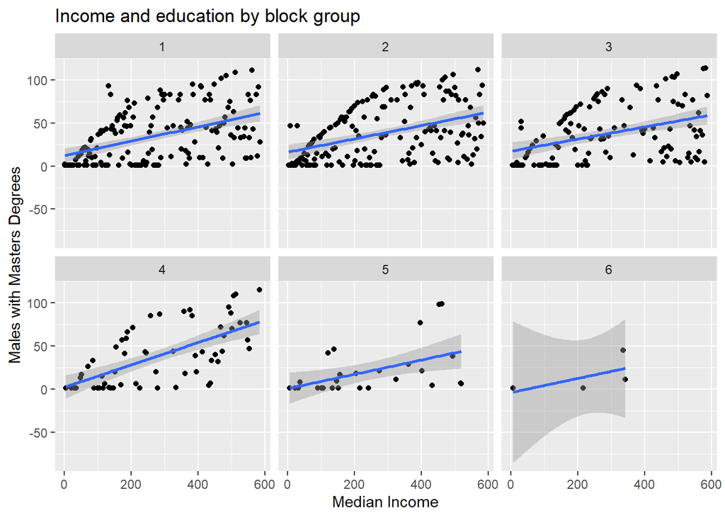

```r
#coerce vars to numeric
my_tibble$population_white <- as.numeric(my_tibble$population_white)
my_tibble$population_black <- as.numeric(my_tibble$population_black)
my_tibble$median_household_income <- as.numeric(my_tibble$median_household_income)
my_tibble$masters_degree_male <- as.numeric(my_tibble$masters_degree_male)
#set-up scatter plots with regression and facet by block group
g1 <- ggplot(data = my_tibble, aes(x = my_tibble$median_household_income,y = my_tibble$masters_degree_male))
g1 + geom_point() + geom_smooth(method = lm) +facet_wrap(~my_tibble$block_group) + labs(title = "Income and education by block group", y= "Males with Masters Degrees",x="Median Income")
```

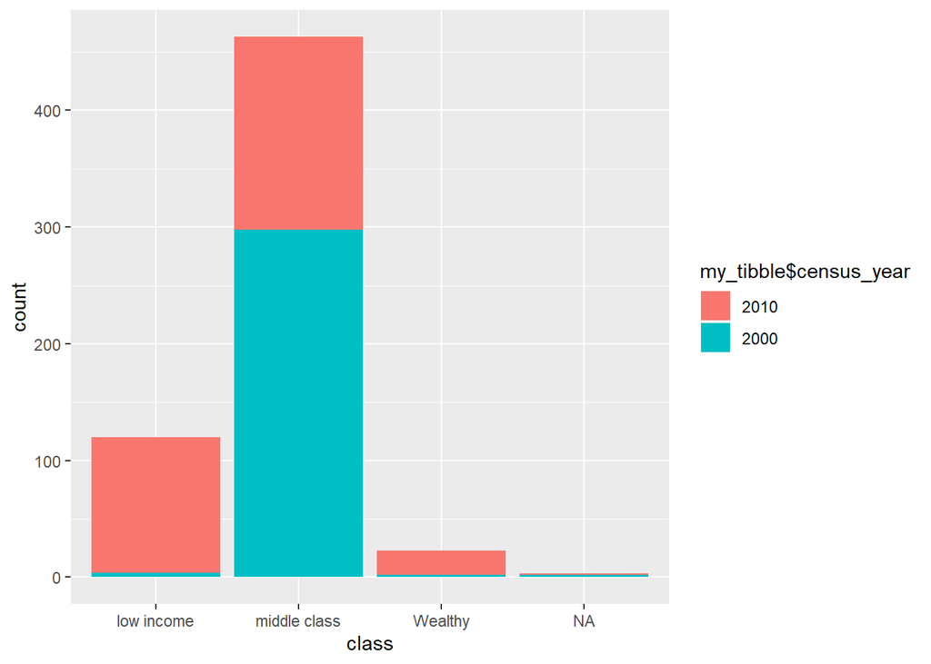

```r
g2 <- ggplot(my_tibble,aes(x=class)) + geom_histogram(stat = "count", aes(fill = my_tibble$census_year))
g2
```

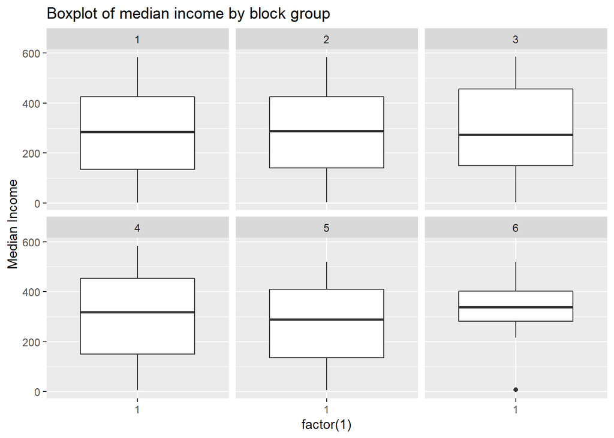

```r
g3 <- ggplot(xml_df_nodup, aes( x = factor(1)))
g3 + geom_boxplot(aes(y=my_tibble$median_household_income)) + facet_wrap(~my_tibble$block_group) + labs(title="Boxplot of median income by block group", y = "Median Income")
```

```r
my_summary <- function(x){
  mean <- mean(x, na.rm = TRUE)
  stdev <- sd(x, na.rm = TRUE)
return(list(mean,stdev))
}
my_tibble$masters_degree_female <- as.numeric(my_tibble$masters_degree_female)
my_summary <- my_summary(my_tibble$masters_degree_female)
my_summary_nolist <- unlist(my_summary)
summary_matrix <- matrix(my_summary_nolist,ncol = 2)
colnames(summary_matrix) <- c("Mean","Std dev")
summary_matrix
```

```
##          Mean  Std dev
## [1,] 40.26703 33.85573
```

After conducting this initial exploratory data analysis, it would be interesting to further explore the factors that could predict median household income. Our data suggests that level of education has some impact but what about whether you own or rent a home? What about the relationship between race and income?